Skip to main content

# Predicting Food Delivery Time from Order and External Conditions

Author

Steven Mou, Owen Lin, Rachel Lee, Shravan Chandra

Published

November 21, 2026

```python
import numpy as np
import pandas as pd
import altair as alt

# Save charts as PNG images in the report
_ = alt.renderers.enable("png", scale_factor=2)
```

# Summary

This project investigates whether food delivery times can be predicted using order characteristics and external conditions, including traffic density, weather, and time of day. Using the Food Delivery Dataset published by Gaurav Malik [1], we develop and compare regression models to predict recorded delivery durations in minutes. Model performance is evaluated primarily using mean absolute error (MAE), which expresses prediction error in minutes. The best-performing model was a tuned decision tree (maximum depth 15, minimum leaf size 40), which achieved a test MAE of 3.37 minutes and an R² of 0.80, compared to a linear regression baseline with an MAE of 4.77 minutes and an R² of 0.60. Permutation importance showed that the model relied most on weather and traffic density, followed by distance and courier rating. These findings may help improve delivery-time estimation, although limitations in the dataset and the observational nature of the analysis restrict their generalizability. A delivery app user at home should also expect longer waits during traffic jams and in cloudy or foggy weather.

# Introduction

Online food delivery services rely on accurate delivery-time estimates to manage customer expectations and improve operational efficiency. However, delivery times can vary considerably depending on factors such as travel distance, traffic congestion, weather conditions, and order timing. Previous research has explored machine learning approaches for estimating food delivery arrival times, demonstrating their potential to improve prediction accuracy and support delivery operations [2, 3].

This project aims to answer the following research question: To what extent can food delivery times be predicted using order characteristics, delivery conditions, and external factors such as traffic, weather, and time of day? In addition to evaluating predictive performance, we investigate which recorded factors are most strongly associated with variation in delivery times. Understanding these relationships may provide insights into the conditions under which deliveries tend to take longer, although these associations do not necessarily imply causation.

To investigate this question, we use the Food Delivery Dataset published by Gaurav Malik on Kaggle [1]. Each observation represents an individual food delivery and contains information about the order, delivery personnel, geographic locations, weather, traffic conditions, and other delivery characteristics. Our response variable is the recorded delivery time, measured in minutes. Candidate predictors include the type of order, order time, distance between the restaurant and delivery location, road traffic density, and weather conditions. We use supervised regression methods to predict delivery duration and evaluate their performance on later, held-out observations.

# Methods

## Data

The dataset used in this project is version 1 of the “Food Delivery Dataset” published by Gaurav Malik on Kaggle [1]. This dataset contains individual food delivery records which contain information about delivery personnel, order characteristics, geographic conditions, weather conditions, and road traffic density.

Each row in this dataset represents a single food delivery order, and the response variable is the recorded delivery duration in minutes (`Time_taken(min)`).

We use these observations to investigate whether delivery times can be predicted accurately from the characteristics of the food orders along with external conditions. The original dataset can be found [here](https://www.kaggle.com/datasets/gauravmalik26/food-delivery-dataset).

We downloaded the data using the KaggleHub Python package and saved the raw CSV files under `data/raw/` directory to support reproducibility.

```python
from pathlib import Path
import kagglehub
import shutil


DATA_DIR = Path("data")  # Quarto runs code from the project root (see _quarto.yml)
RAW_DIR = DATA_DIR / "raw"
PROCESSED_DIR = DATA_DIR / "processed"

# Create the folders in data if they don't exist
RAW_DIR.mkdir(parents=True, exist_ok=True)
PROCESSED_DIR.mkdir(parents=True, exist_ok=True)
```

### Downloading the Data

```python
# Download the original data into data/raw/
dataset_path = Path(kagglehub.dataset_download("gauravmalik26/food-delivery-dataset/versions/1"))

# Original dataset is given as training and test sets
for filename in ['train.csv', 'test.csv']:
    source = dataset_path / filename
    destination = RAW_DIR / filename

    if source.resolve() != destination.resolve():
        shutil.copy2(source, destination)

raw_train = pd.read_csv(RAW_DIR / 'train.csv')
raw_test = pd.read_csv(RAW_DIR / 'test.csv')
```

### Inspecting the Data

```python
print("Original train shape:", raw_train.shape)
print("Original test shape:", raw_test.shape)

print("\nOriginal train columns:")
print(raw_train.columns.tolist())

print("\nOriginal test columns:")
print(raw_test.columns.tolist())
```

```
Original train shape: (45593, 20)
Original test shape: (11399, 19)

Original train columns:
['ID', 'Delivery_person_ID', 'Delivery_person_Age', 'Delivery_person_Ratings', 'Restaurant_latitude', 'Restaurant_longitude', 'Delivery_location_latitude', 'Delivery_location_longitude', 'Order_Date', 'Time_Orderd', 'Time_Order_picked', 'Weatherconditions', 'Road_traffic_density', 'Vehicle_condition…

Original test columns:
['ID', 'Delivery_person_ID', 'Delivery_person_Age', 'Delivery_person_Ratings', 'Restaurant_latitude', 'Restaurant_longitude', 'Delivery_location_latitude', 'Delivery_location_longitude', 'Order_Date', 'Time_Orderd', 'Time_Order_picked', 'Weatherconditions', 'Road_traffic_density', 'Vehicle_condition…
```

The original idea here was to merge the given train and test sets if the shapes of the two dataframes were compatible. However, after inspection, we can see that the raw test dataset does not have the target variable of `Time_taken(min)`. Therefore, we will use the original training dataset as our complete labelled dataset and partition it into training and test sets for our analysis.

```python
full_data = raw_train.copy()
```

## Analysis

### Splitting the data

```python
# Parse dates to determine the chronological split
order_dates = pd.to_datetime(
    full_data["Order_Date"].astype("string").str.strip(),
    format="%d-%m-%Y",
    errors="coerce"
)

print("Earliest date:", order_dates.min())
print("Latest date:", order_dates.max())
print("Number of unique dates:", order_dates.nunique())
print("Missing dates:", order_dates.isna().sum())
```

```
Earliest date: 2022-02-11 00:00:00
Latest date: 2022-04-06 00:00:00
Number of unique dates: 44
Missing dates: 0
```

Before any exploration, we hold out the last 11 days of orders (from March 27, 2022, about 25% of the data) as the test set. Splitting by date rather than at random means the model is evaluated on orders placed after every order it learned from, as it would be when used in practice. The test set is not used again until the final evaluation.

```python
assert full_data["ID"].is_unique, "An order ID appears twice and could land in both sets"

full_data["Order_Date"] = pd.to_datetime(
    full_data["Order_Date"].str.strip(),
    format="%d-%m-%Y",
    errors="coerce"
)

test_start = pd.Timestamp("2022-03-27")
train_df = full_data[full_data["Order_Date"] < test_start].copy()
test_df = full_data[full_data["Order_Date"] >= test_start].copy()

train_df.to_csv(PROCESSED_DIR / "train.csv", index=False)
test_df.to_csv(PROCESSED_DIR / "test.csv", index=False)

# Display date ranges
print(f"Training set: {len(train_df):,} orders ({train_df['Order_Date'].min():%b %d} to {train_df['Order_Date'].max():%b %d})")
print(f"Test set: {len(test_df):,} orders ({test_df['Order_Date'].min():%b %d} to {test_df['Order_Date'].max():%b %d})")
```

```
Training set: 34,042 orders (Feb 11 to Mar 26)
Test set: 11,551 orders (Mar 27 to Apr 06)
```

### Clean the data

The training and test datasets were both cleaned separately using the same transformations. We standardized formats, derived straight-line delivery distance, and removed duplicate rows and rows missing an order date or delivery time. Placeholder coordinates (values near zero) yield a missing distance.

We save the cleaned data to `data/processed/` folder in `train.csv` and `test.csv`.

```python
def haversine_km(lat1, lon1, lat2, lon2):
    """Computes the straight-line distance between two locations (using latitude and longitude) in kilometres."""
    lat1, lon1, lat2, lon2 = map(np.radians, (lat1, lon1, lat2, lon2))
    a = (np.sin((lat2 - lat1) / 2) ** 2
         + np.cos(lat1) * np.cos(lat2) * np.sin((lon2 - lon1) / 2) ** 2)
    return 6371 * 2 * np.arcsin(np.sqrt(a))
```

We define a cleaning function to be used on both train and test sets.

```python
def clean_data(data):
    df = data.copy()

    # standardize column names
    df.columns = df.columns.str.strip()

    for col in df.select_dtypes(exclude='number').columns:
        df[col] = df[col].astype(str).str.strip().replace({"NaN": np.nan, "nan": np.nan})

    # Cleaning weather conditions
    df["Weatherconditions"] = df["Weatherconditions"].str.replace("conditions ", "", regex=False).replace("NaN", np.nan)

    # Convert target to numeric (minutes)
    df["target"] = pd.to_numeric(df["Time_taken(min)"].astype(str).str.replace("(min) ", "", regex=False), errors='coerce')

    df["Age"] = pd.to_numeric(df["Delivery_person_Age"])
    df["Rating"] = pd.to_numeric(df["Delivery_person_Ratings"])
    df['Rating'] = df['Rating'].where(df['Rating'].between(1,5))
    df["multiple_deliveries"] = pd.to_numeric(df["multiple_deliveries"])
    df['Vehicle_condition'] = pd.to_numeric(df['Vehicle_condition'])

    df["date"] = pd.to_datetime(df["Order_Date"])

    # Create a day of week column
    df["dow"] = df["date"].dt.day_of_week

    # Create an order hour column
    df["order_hour"] = pd.to_datetime(df["Time_Orderd"], format="%H:%M:%S", errors="coerce").dt.hour

    # Converting coordinates to numeric
    coord_cols = ["Restaurant_latitude", "Restaurant_longitude", "Delivery_location_latitude", "Delivery_location_longitude"]
    coords = df[coord_cols].abs()  # Correct sign errors in this dataset
    coords = coords.where((coords >= 1).all(axis=1), axis=0)  # Placeholder coordinates become missing

    # Calculate distances
    df["dist_km"] = haversine_km(*(coords[col] for col in coord_cols))

    processed_cols = ["ID", "Age", "Rating", "Vehicle_condition", "Type_of_vehicle", "multiple_deliveries",
                  "Weatherconditions", "Road_traffic_density", "Type_of_order", "Festival", "City",
                  "date", "dow", "order_hour", "dist_km", "target"]

    cleaned = df[processed_cols].drop_duplicates().dropna(subset=["date", "target"]).loc[lambda x: x['target'] > 0].reset_index(drop=True)

    return cleaned
```

```python
train_clean = clean_data(train_df)
test_clean = clean_data(test_df)

train_clean.to_csv(PROCESSED_DIR / "train.csv", index=False)
test_clean.to_csv(PROCESSED_DIR / "test.csv", index=False)
```

### Exploratory Data Analysis

We conducted an exploratory data analysis using only the training data `train_clean` to investigate the distribution of delivery times and its relationships with the available features. In particular, we examined delivery distance, weather conditions, road traffic density and order hour since these variables are directly relevant to our research question.

First, we summarized the numerical features and investigated for possible missing values. Then, we created visualizations from the data to identify potential patterns that we can use for the regression modelling. The test set was excluded from the analysis to avoid any data leakage.

```python
numeric_cols = ['target', 'dist_km', 'Age', 'Rating', 'order_hour', 'multiple_deliveries']

numeric_summary = train_clean[numeric_cols].describe().T

numeric_summary.round(2)
```

Table 1: Summary statistics for selected numerical variables in the training dataset.

|  | count | mean | std | min | 25% | 50% | 75% | max |
| --- | --- | --- | --- | --- | --- | --- | --- | --- |
| target | 34042.0 | 26.24 | 9.36 | 10.00 | 19.00 | 26.00 | 32.00 | 54.00 |
| dist_km | 31136.0 | 9.59 | 5.60 | 1.47 | 4.66 | 9.12 | 13.61 | 20.97 |
| Age | 32658.0 | 29.58 | 5.82 | 15.00 | 25.00 | 30.00 | 35.00 | 50.00 |
| Rating | 32557.0 | 4.63 | 0.33 | 1.00 | 4.50 | 4.70 | 4.90 | 5.00 |
| order_hour | 32730.0 | 17.36 | 4.85 | 0.00 | 15.00 | 19.00 | 21.00 | 23.00 |
| multiple_deliveries | 33295.0 | 0.74 | 0.57 | 0.00 | 0.00 | 1.00 | 1.00 | 3.00 |

```python
categorical_cols = [
    "Vehicle_condition",
    "Type_of_vehicle",
    "Weatherconditions",
    "Road_traffic_density",
    "Type_of_order",
    "Festival",
    "City",
    "dow"
]

train_clean[categorical_cols].astype("string").describe().T
```

Table 2: Summary of categorical variables in the training dataset.

|  | count | unique | top | freq |
| --- | --- | --- | --- | --- |
| Vehicle_condition | 34042 | 4 | 0 | 11238 |
| Type_of_vehicle | 34042 | 4 | motorcycle | 19727 |
| Weatherconditions | 33576 | 6 | Fog | 5695 |
| Road_traffic_density | 33591 | 4 | Low | 11629 |
| Type_of_order | 34042 | 4 | Snack | 8630 |
| Festival | 33881 | 2 | No | 33217 |
| City | 33149 | 3 | Metropolitian | 25406 |
| dow | 34042 | 7 | 4 | 5898 |

Table 1 shows that the cleaned training dataset contains 34,042 delivery observations with delivery times ranging from 10 to 54 minutes with a mean of 26.24 minutes and standard deviation of 9.36 minutes. This showed substantial variation in delivery times. Additionally, we see straight-line distances averaging 9.59 km with observed distances ranging from 1.47 km to 20.97 km.

The categorical features (Table 2) show us that motorcycles are the most common delivery vehicle type with over 50% of deliveries made on motorcycles. Metropolitan areas account for over 75% of non-missing city-category observations and only 2.0% of non-missing festival observations occur during festivals. We’ll have to account for these imbalances during interpretation of the regression results, particularly for the less frequently observed delivery conditions.

```python
missing_summary = pd.DataFrame({
    "Missing Count": train_clean.isna().sum(),
    "Missing (%)": train_clean.isna().mean() * 100
})

missing_summary.sort_values("Missing Count", ascending=False).round(2)
```

Table 3: Missing values in the processed training dataset.

|  | Missing Count | Missing (%) |
| --- | --- | --- |
| dist_km | 2906 | 8.54 |
| Rating | 1485 | 4.36 |
| Age | 1384 | 4.07 |
| order_hour | 1312 | 3.85 |
| City | 893 | 2.62 |
| multiple_deliveries | 747 | 2.19 |
| Weatherconditions | 466 | 1.37 |
| Road_traffic_density | 451 | 1.32 |
| Festival | 161 | 0.47 |
| ID | 0 | 0.00 |
| Vehicle_condition | 0 | 0.00 |
| Type_of_vehicle | 0 | 0.00 |
| Type_of_order | 0 | 0.00 |
| date | 0 | 0.00 |
| dow | 0 | 0.00 |
| target | 0 | 0.00 |

We see from Table 3 that the straight-line distance has the highest proportion of missing observations (8.54%) followed by rating (4.36%), age (4.07%) and order hour (3.85%). All remaining predictors have less than 3% missing values. Since all predictors have a relatively low proportion of missing observations, we’ll retain these features for regression modelling. However, the missing numerical and categorical values will be imputed within the modelling pipeline.

We’ll start by examining the distribution of recorded delivery times in the training dataset.

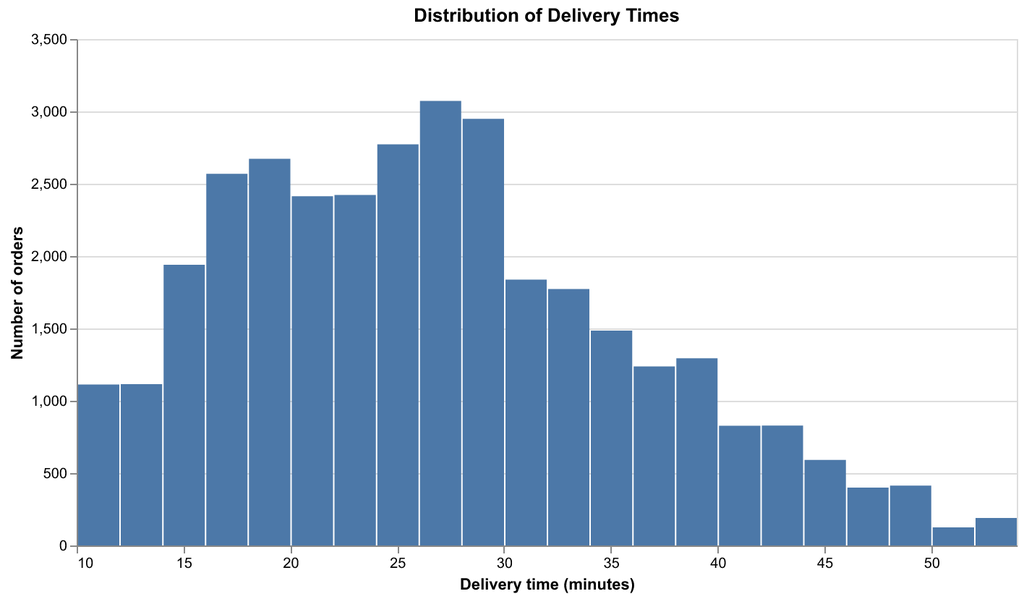

Figure 1: Distribution of delivery times in the training dataset.

```python
# Count orders at each recorded delivery time
delivery_counts = (
    train_clean["target"]
    .value_counts()
    .rename_axis("delivery_time")
    .reset_index(name="count")
)

delivery_distribution = (
    alt.Chart(delivery_counts).mark_bar().encode(
        x=alt.X("delivery_time:Q",bin=alt.Bin(step=2),title="Delivery time (minutes)",axis=alt.Axis(values=list(range(10, 55, 5)),format=".0f")),
        y=alt.Y("sum(count):Q",title="Number of orders")
    ).properties(width=650, height=350, title="Distribution of Delivery Times")
)

delivery_distribution
```

Figure 1 shows the distribution of delivery times in the training dataset. With delivery times ranging from 10 to 54 minutes, it seems to be slightly right-skewed with the greatest concentration of observations occurring between 24 and 30 minutes. The distribution progressively has far fewer deliveries taking longer than 30 minutes. However, from the numerical summaries above, we see that the mean 26.24 minutes is quite similar to the median of 26 minutes, which suggests limited overall skewness.

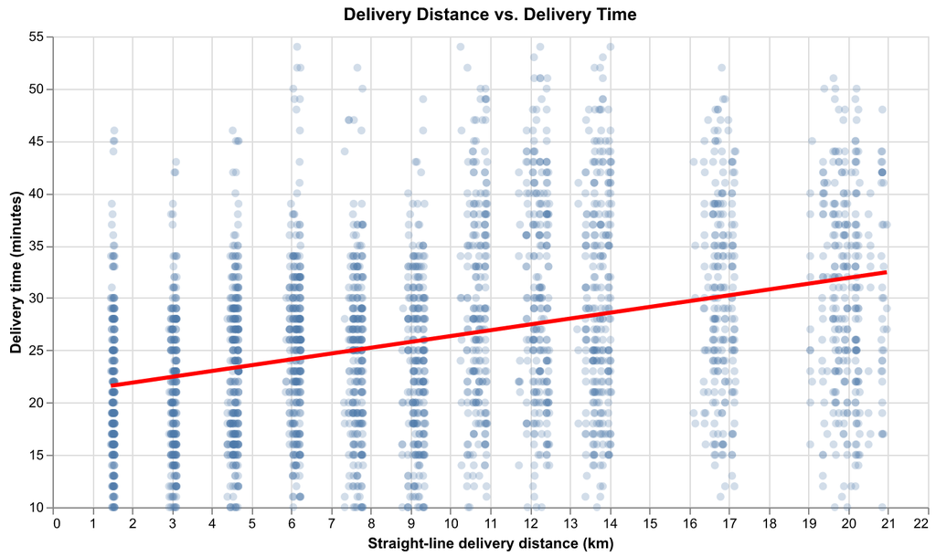

Figure 2: Relationship between straight-line delivery distance and delivery time, using a sample of training observations.

```python
distance_data = train_clean[["dist_km", "target"]].dropna()

distance_sample = distance_data.sample(n=min(3000, len(distance_data)), random_state=522)

scatter = alt.Chart(distance_sample).mark_circle(opacity=0.25, size=35).encode(
    x=alt.X("dist_km:Q", title="Straight-line delivery distance (km)", scale=alt.Scale(zero=False)),
    y=alt.Y("target:Q", title="Delivery time (minutes)", scale=alt.Scale(zero=False)),
    tooltip=[
        alt.Tooltip("dist_km:Q", format=".2f", title="Distance (km)"),
        alt.Tooltip("target:Q", format=".0f", title="Delivery time (min)")
    ]
)

regression_line = alt.Chart(distance_sample).transform_regression("dist_km","target").mark_line(color="red", size=3).encode(x="dist_km:Q",y="target:Q")

distance_plot = (scatter + regression_line).properties(width=650, height=350, title="Delivery Distance vs. Delivery Time")

distance_plot
```

Figure 2 shows a positive association between straight-line delivery distance and delivery time, as we can see from the upward-sloping regression line. However, we also see substantial variation in delivery times at similar distances which suggests that distance alone can’t fully explain delivery time. The distances shown in the plot also exhibit distinct vertical clusters which potentially reflect systematic increments in the recorded geographic coordinates.

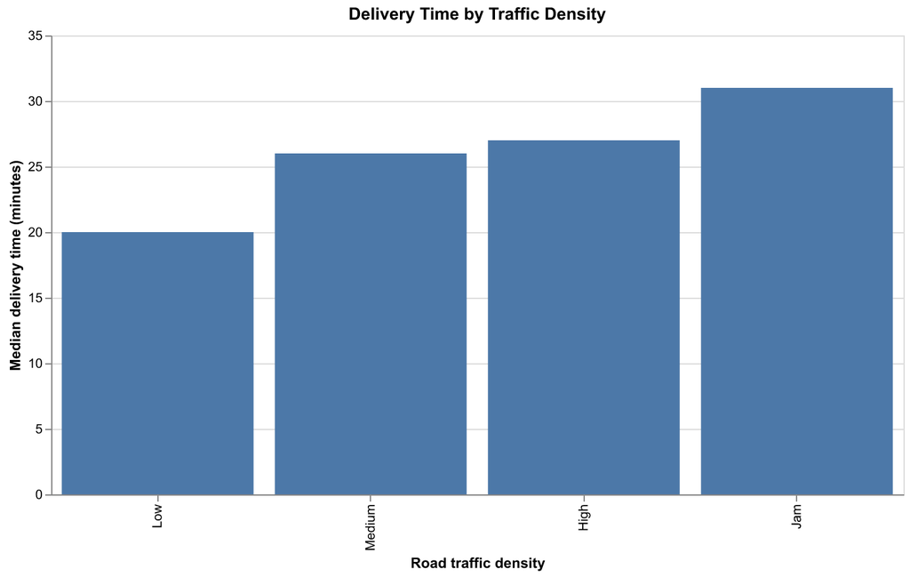

Figure 3: Median delivery time by road traffic density in the training dataset.

```python
# Calculate median delivery time for each traffic category
traffic_summary = (
    train_clean
    .groupby("Road_traffic_density")["target"]
    .agg(["median", "count"])
    .reset_index()
)

# Plot median delivery time by traffic density
traffic_plot = alt.Chart(traffic_summary).mark_bar().encode(
    x=alt.X("Road_traffic_density:N", sort=["Low", "Medium", "High", "Jam"], title="Road traffic density"),
    y=alt.Y("median:Q", title="Median delivery time (minutes)"),
    tooltip=[
        alt.Tooltip("Road_traffic_density:N", title="Traffic density"),
        alt.Tooltip("median:Q", title="Median delivery time", format=".1f"),
        alt.Tooltip("count:Q", title="Number of orders")
    ]
).properties(width=650, height=350, title="Delivery Time by Traffic Density")


traffic_plot
```

Figure 3 shows a positive association between road traffic density and delivery time. The median delivery time increases from 20 minutes under low traffic to 31 minutes during traffic jams which is a difference of 11 minutes. Additionally, we also see that under medium and high traffic conditions, the median delivery times are about the same at 26 and 27 minutes, respectively. The differences shown here suggest that traffic density could be an important predictor of delivery time.

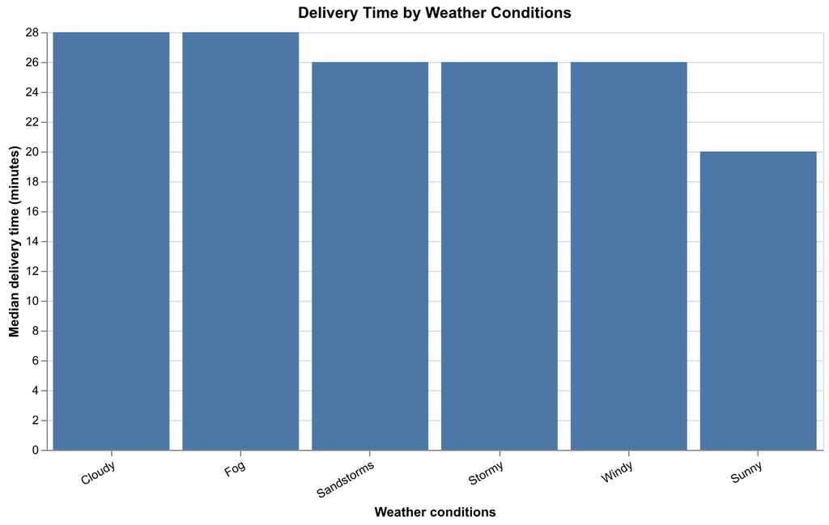

Figure 4: Median delivery time by weather condition in the training dataset.

```python
# Calculate median delivery time for each weather condition
weather_summary = train_clean.groupby("Weatherconditions")["target"].agg(["median", "count"]).reset_index()

# Plot median delivery time by weather condition
weather_plot = alt.Chart(weather_summary).mark_bar().encode(
    x=alt.X("Weatherconditions:N", sort=alt.SortField(field="median", order="descending"), title="Weather conditions", axis=alt.Axis(labelAngle=-30)),
    y=alt.Y("median:Q", title="Median delivery time (minutes)"),
    tooltip=[
        alt.Tooltip("Weatherconditions:N", title="Weather condition" ),
        alt.Tooltip("median:Q", title="Median delivery time", format=".1f"),
        alt.Tooltip("count:Q",title="Number of orders")
    ]
).properties(width=650, height=350, title="Delivery Time by Weather Conditions")


weather_plot
```

Figure 4 shows us differences in the median delivery times under different weather conditions. We can see that sunny weather conditions have the shortest median delivery time at 20 minutes, while cloudy and foggy weather have the longest times at 28 minutes. Sandstorms, stormy weather and windy weather all have median delivery times of 26 minutes. Thus, the groupings suggest that different weather categories are associated with noticeably different typical delivery times. However, in each of the three groupings within this plot, we can see that the similar medians within each group can suggest that some weather conditions can provide comparable predictive information. This makes weather another potentially useful predictor of delivery time.

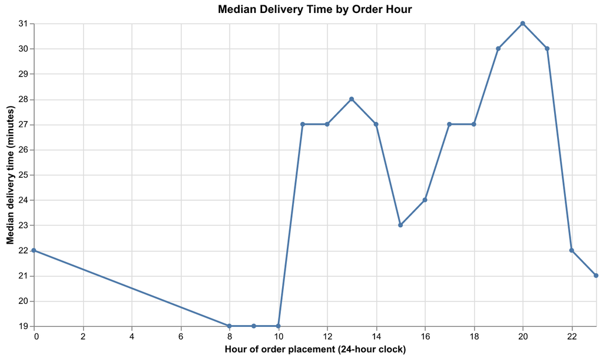

Figure 5: Median delivery time by hour of order placement in the training dataset.

```python
# Calculate median delivery time and order count by hour
hour_summary = train_clean.groupby("order_hour")["target"].agg(["median", "count"]).reset_index()


# Plot median delivery time by order hour
hour_plot = alt.Chart(hour_summary).mark_line(point=True).encode(
    x=alt.X("order_hour:Q", title="Hour of order placement (24-hour clock)", axis=alt.Axis(values=list(range(0, 24, 2))), scale=alt.Scale(domain=[0, 23])),
    y=alt.Y("median:Q", title="Median delivery time (minutes)", scale=alt.Scale(zero=False)),
    tooltip=[
        alt.Tooltip("order_hour:Q", title="Order hour", format=".0f"),
        alt.Tooltip("median:Q", title="Median delivery time", format=".1f"),
        alt.Tooltip("count:Q", title="Number of orders")
    ]
).properties(width=650, height=350, title="Median Delivery Time by Order Hour")


hour_plot
```

Figure 5 shows the median delivery times varying considerably depending on the hour the delivery was ordered. The longest median delivery times occur during the evening hours, especially between 19:00 and 21:00 which peaks at 20:00 with a delivery time of 31 minutes. The sharpest increase also happens from the hours 11:00 to 14:00, when the median delivery times range from 27-28 minutes. These periods may very well coincide with the typical dinner and lunch hours which suggests that there’s increased demand for food delivery and may contribute to longer delivery times. In contrast, the orders placed between 8:00 and 10:00 have a median delivery time of 19 minutes. The noticeable differences across hours suggest that the timing of the order could be an important predictor of delivery time.

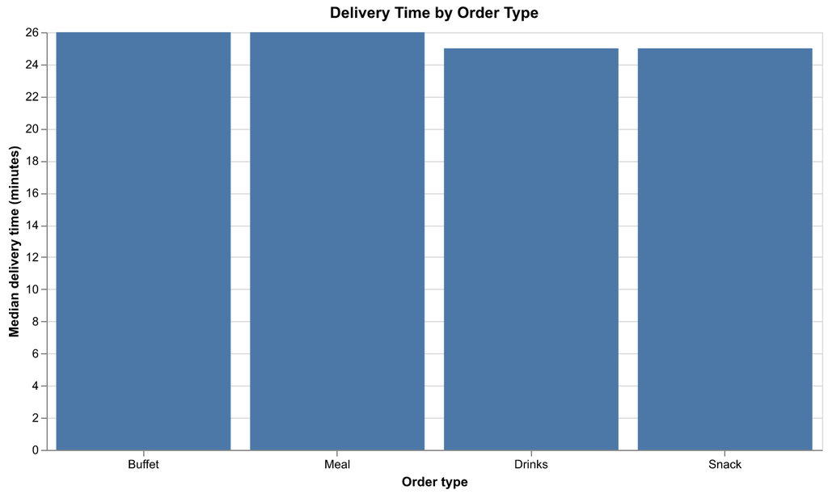

Figure 6: Median delivery time by order type in the training dataset.

```python
# Calculate median delivery time and order count by order type
order_summary = train_clean.groupby("Type_of_order")["target"].agg(["median", "count"]).reset_index()


# Plot median delivery time by order type
order_plot = alt.Chart(order_summary).mark_bar().encode(
    x=alt.X("Type_of_order:N", sort=alt.SortField(field="median", order="descending"), title="Order type", axis=alt.Axis(labelAngle=0)),
    y=alt.Y("median:Q", title="Median delivery time (minutes)"),
    tooltip=[
        alt.Tooltip("Type_of_order:N", title="Order type"),
        alt.Tooltip("median:Q", title="Median delivery time", format=".1f"),
        alt.Tooltip("count:Q", title="Number of orders")
    ]
).properties(width=650, height=350, title="Delivery Time by Order Type")


order_plot
```

Figure 6 shows the median delivery times across different order types, but they’re relatively consistent. The median delivery times of buffets and meals are 26 minutes which is not that much different from the median delivery times of drinks and snacks which are 25 minutes. The very small difference of 1 minute seems to suggest that order type may have a weaker association with delivery time compared to other external factors such as traffic density and weather conditions which we have seen to show larger differences in median delivery times.

## Models

We predict delivery time in minutes from information that is known when an order is dispatched: courier age, rating and vehicle, the number of deliveries the courier is carrying, straight-line distance, order hour, day of the week, weather, traffic, order type, festival and area type. We first remove the orders with impossible courier details (age 15 or 50, or a rating of 1 or 6).

We judge models by mean absolute error (MAE), the average number of minutes a prediction is off by, because it is easy to interpret for an estimated delivery time. To choose between models without touching the test set, we hold out the last week of the training data (March 20 to 26) as a validation set, again so that models are evaluated on later orders than they learned from. Each model is a pipeline that fills in missing values (the median for numeric inputs, plus an indicator of which values were missing, and a “Missing” category for categorical inputs), scales numeric inputs and one-hot encodes categorical inputs. These steps are learned from the training rows only.

```python
from sklearn.compose import make_column_transformer
from sklearn.impute import SimpleImputer
from sklearn.linear_model import LinearRegression
from sklearn.model_selection import GridSearchCV, PredefinedSplit, cross_val_score
from sklearn.pipeline import make_pipeline
from sklearn.preprocessing import OneHotEncoder, StandardScaler
from sklearn.svm import SVR
from sklearn.tree import DecisionTreeRegressor


def drop_impossible(data):
    return data[~(data["Age"].isin([15, 50]) | data["Rating"].isin([1, 6]))]


numeric_cols = ["Age", "Rating", "Vehicle_condition", "multiple_deliveries", "dist_km", "order_hour", "dow"]
categorical_cols = ["Weatherconditions", "Road_traffic_density", "Type_of_vehicle", "Type_of_order",
                    "Festival", "City"]
features = numeric_cols + categorical_cols

model_train = drop_impossible(train_clean)
model_test = drop_impossible(test_clean)
X_train, y_train = model_train[features], model_train["target"]
X_test, y_test = model_test[features], model_test["target"]

# Fold 0 is the last week of training orders; the earlier orders (-1) are only used for fitting
validation = PredefinedSplit(np.where(model_train["date"] >= pd.Timestamp("2022-03-20"), 0, -1))

preprocessor = make_column_transformer(
    (make_pipeline(SimpleImputer(strategy="median", add_indicator=True), StandardScaler()), numeric_cols),
    (make_pipeline(SimpleImputer(strategy="constant", fill_value="Missing"),
                   OneHotEncoder(handle_unknown="ignore")), categorical_cols),
)
```

We compare three models with their default settings (Table 4). Linear regression is the baseline. A decision tree can capture interactions, such as traffic mattering more for long trips, and support vector regression (SVR) can capture smooth non-linear patterns.

```python
models = {
    "Linear regression (baseline)": LinearRegression(),
    "Decision tree": DecisionTreeRegressor(random_state=0),
    "SVR": SVR(),
}
validation_mae = {
    name: -cross_val_score(make_pipeline(preprocessor, model), X_train, y_train,
                           cv=validation, scoring="neg_mean_absolute_error").mean()
    for name, model in models.items()
}
pd.DataFrame({"Validation MAE (min)": validation_mae}).round(2)
```

Table 4: Validation MAE of each model with default settings.

|  | Validation MAE (min) |
| --- | --- |
| Linear regression (baseline) | 4.79 |
| Decision tree | 4.20 |
| SVR | 4.02 |

Both non-linear models improve on the baseline. We choose to tune the decision tree rather than SVR because a single prediction can be traced through its split rules, which makes it easier to explain an estimated delivery time. An unrestricted tree fits the training orders too closely, so we search for the maximum depth and minimum leaf size that give the lowest validation MAE (Table 5). The best settings are then refitted on all training orders.

```python
tree_search = GridSearchCV(
    make_pipeline(preprocessor, DecisionTreeRegressor(random_state=0)),
    param_grid={
        "decisiontreeregressor__max_depth": [10, 15, 20, None],
        "decisiontreeregressor__min_samples_leaf": [20, 40, 60, 100],
    },
    cv=validation,
    scoring="neg_mean_absolute_error",
)
tree_search.fit(X_train, y_train)

tuning = pd.DataFrame({
    "Maximum depth": tree_search.cv_results_["param_decisiontreeregressor__max_depth"],
    "Minimum leaf size": tree_search.cv_results_["param_decisiontreeregressor__min_samples_leaf"],
    "Validation MAE (min)": -tree_search.cv_results_["mean_test_score"],
})
tuning.fillna({"Maximum depth": "Unlimited"}).nsmallest(5, "Validation MAE (min)").style.format(precision=2).hide()
```

Table 5: The five decision tree settings with the lowest validation MAE.

| Maximum depth | Minimum leaf size | Validation MAE (min) |
| --- | --- | --- |
| 15 | 40 | 3.30 |
| 20 | 40 | 3.31 |
| Unlimited | 40 | 3.31 |
| 15 | 60 | 3.31 |
| 20 | 60 | 3.31 |

# Results

Table 6 shows how each model performs on the test orders, which were not used for any of the choices above. The other models are refitted on all training orders so that every model has seen the same data. Only the decision tree was tuned, which gives it an advantage over the other models.

```python
from sklearn.metrics import mean_absolute_error, r2_score

fitted = {name: make_pipeline(preprocessor, model).fit(X_train, y_train) for name, model in models.items()}
fitted["Tuned decision tree"] = tree_search.best_estimator_

test_scores = pd.DataFrame({
    name: {"Test MAE (min)": mean_absolute_error(y_test, model.predict(X_test)),
           "R²": r2_score(y_test, model.predict(X_test))}
    for name, model in fitted.items()
}).T
test_scores.sort_values("Test MAE (min)").round(2)
```

Table 6: Performance on the held-out test orders. R² is the proportion of the variation in delivery time that the model explains.

|  | Test MAE (min) | R² |
| --- | --- | --- |
| Tuned decision tree | 3.37 | 0.80 |
| SVR | 3.99 | 0.71 |
| Decision tree | 4.28 | 0.64 |
| Linear regression (baseline) | 4.77 | 0.60 |

To see which inputs the tuned tree relies on most, we shuffle one input at a time and measure how much the test MAE increases (permutation importance, Figure 7). Inputs that are related to each other can share importance.

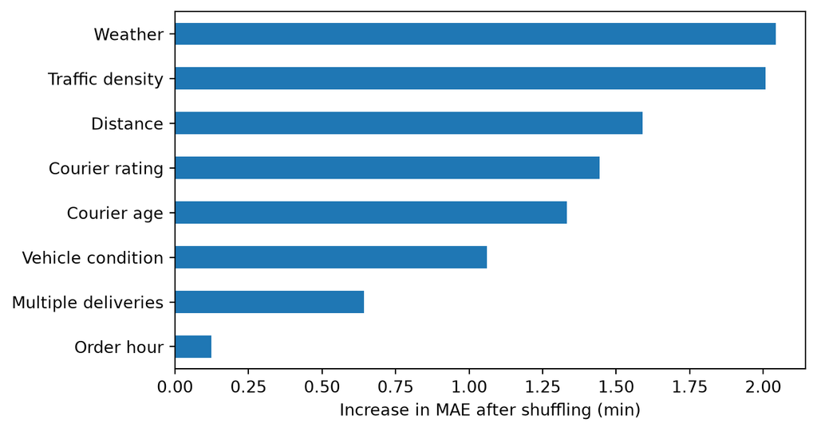

Figure 7: Increase in test MAE when each input is shuffled, for the eight most important inputs of the tuned decision tree (2,000 test orders).

```python
import matplotlib.pyplot as plt
from sklearn.inspection import permutation_importance

labels = {
    "Age": "Courier age", "Rating": "Courier rating", "Vehicle_condition": "Vehicle condition",
    "multiple_deliveries": "Multiple deliveries", "dist_km": "Distance", "order_hour": "Order hour",
    "dow": "Day of the week", "Weatherconditions": "Weather", "Road_traffic_density": "Traffic density",
    "Type_of_vehicle": "Vehicle type", "Type_of_order": "Order type", "Festival": "Festival",
    "City": "Area type",
}
sample = X_test.sample(2000, random_state=0)
importance = permutation_importance(tree_search.best_estimator_, sample, y_test[sample.index],
                                    scoring="neg_mean_absolute_error", n_repeats=5, random_state=0)
top = pd.Series(importance.importances_mean, index=features).rename(labels).nlargest(8).sort_values()

fig, ax = plt.subplots(figsize=(7, 4))
top.plot.barh(ax=ax)
ax.set(xlabel="Increase in MAE after shuffling (min)", ylabel="")
plt.show()
```

# Discussion

We started this project to examine how well food delivery times can be predicted from their order details and external conditions. Our tuned decision tree shows that they can be predicted fairly well, as it predicted delivery times for later, unseen orders with an MAE of 3.37 minutes and an R² of 0.80. It outperformed a linear regression baseline, which had an MAE of 4.77 minutes and an R² of 0.60.

Our modelling produced several findings that matched what we expected after performing exploratory data analysis. Weather, traffic density, and distance all exhibited clear differences in median delivery time and these were the three most important inputs as measured by permutation importance. However, we also encountered an unexpected result. Median delivery time varied heavily with the hour of order placement, yet it was the least important of the eight inputs shown in Figure 7. This could be because the busiest hours for orders likely coincide with heavier traffic, meaning that the hour of the order provides limited information once traffic density is known.

Transferring our findings to the real-world context of food delivery orders, our model gives us reason to believe that delivery platforms could improve their time estimates by adjusting for the current weather conditions and traffic, rather than relying mainly on distance. It is possible that more accurate estimates could increase the satisfaction of an ordering customer and reduce complaints and order cancellations. It may also lead to delivery drivers receiving more tips as there would be fewer instances of deliveries taking longer than predicted. There may also be an opportunity for the delivery platforms to use weather and traffic density to optimize courier assignments and pay during periods of inclement weather or heavy traffic. For example, a delivery service with close ties to a ride-hailing service, such as Uber and Uber Eats, may be able to draw from each other’s operations to improve estimated arrival times across both apps [5].

Our analysis also had several limitations. The original source of the data is not documented, meaning the data could be partially or fully synthetic and therefore unreflective of real-world deliveries. The data is also limited to only about two months in 2022, so the model has not had the opportunity to adjust for seasonal changes or long-term trends. We were also limited to using straight-line distance for each order, which does not fully capture the real-world distance a courier must traverse to deliver an order [4]. Since we chose a decision tree rather than SVR for interpretability despite the SVR model scoring better on validation data, we only tuned a decision tree. It is possible that tuning an SVR model could have led to results that were strong enough to override the decision tree’s interpretability. Finally, permutation importance shows which inputs the model relies on rather than what causes deliveries to take longer. Related inputs like order hour and traffic density can share importance with each other.

Future analysis should be performed to study how our model performs on real, documented data collected over a longer period of time. Incorporating real-world travel distance rather than straight-line distance would also improve our model if feasible. Tuning other models, SVR or otherwise, could also show whether a more accurate model is worth losing the interpretability of a decision tree.

# References

1. Malik, G. (2022). Food Delivery Dataset. Kaggle. https://www.kaggle.com/datasets/gauravmalik26/food-delivery-dataset
2. Hildebrandt, F. D., & Ulmer, M. W. (2022). Supervised learning for arrival time estimations in restaurant meal delivery. Transportation Science, 56(4), 1058–1084. https://doi.org/10.1287/trsc.2021.1095
3. Yalçinkaya, E., & Hızıroğlu, O. A. (2024). A comparative analysis of machine learning models for time prediction in food delivery operations. Artificial Intelligence Theory and Applications, 4(1), 43–56. https://dergipark.org.tr/en/pub/aita/article/1459560
4. Gibas, J., Pomykacz, J., & Baranowski, J. (2024). Bayesian modeling of travel times on the example of food delivery: Part 1—Spatial data analysis and processing. Electronics, 13(17), 3387. https://doi.org/10.3390/electronics13173387
5. Binaykiya, T., Hu, X., & Cirit, O. (2022). DeepETA: How Uber predicts arrival times using deep learning. Uber Engineering Blog. https://www.uber.com/en-US/blog/deepeta-how-uber-predicts-arrival-times/